# Parametric inference

MACS 33001 University of Chicago

$$\newcommand{\E}{\mathrm{E}} \newcommand{\Var}{\mathrm{Var}} \newcommand{\Cov}{\mathrm{Cov}} \newcommand{\se}{\text{se}} \newcommand{\Lagr}{\mathcal{L}} \newcommand{\lagr}{\mathcal{l}}$$

## Parametric models

$$\xi \equiv f(x; \theta) : \theta \in \Theta$$

- $\theta$
- Parameter space $\Theta \subset \Re^k$
- How to estimate $\theta$?
- Assume a parametric model
  - Normal
  - Geometric
  - Bernoulli
  - Binomial
- Approximate the parametric model based on observed data

## Parameter of interest

- $T(\theta)$
- If $X \sim N(\mu, \sigma^2)$ then the parameter is $\theta = (\mu, \sigma)$
- Estimate $\mu$
  - Parameter of interest: $\mu = T(\theta)$
  - Nuisance parameter $\sigma$

## Example: Normal distribution

  $$\begin{align}
  \tau &= \Pr (X > 50) = 1 - \Pr (X < 50) = 1 - \Pr \left( \frac{X - \mu}{\sigma} < \frac{50 - \mu}{\sigma} \right) \\
  &= 1 - \Pr \left(Z < \frac{50 - \mu}{\sigma} \right) = 1 - \Phi \left( \frac{50 - \mu}{\sigma} \right)
  \end{align}$$
- Parameter of interest is $\tau = T(\mu, \sigma) = 1 - \Phi \left( \frac{50 - \mu}{\sigma} \right)$

## Maximum likelihood

- Let $X_1, \ldots, X_n$ be IID with PDF $f(x; \theta)$
- Likelihood function
  $$\Lagr_n(\theta) = \prod_{i=1}^n f(X_i; \theta)$$
- Log-likelihood function
  $$\lagr_n (\theta) = \log \Lagr_n(\theta)$$
- Joint density of the data, as a function of $\theta$
- Likelihood function is not a density function

## Maximum likelihood estimator

- $\hat{\theta}_n$
- Value of $\theta$ that maximizes $\Lagr_n(\theta)$
- $\max [\Lagr_n(\theta)] \equiv \max [\lagr_n(\theta)]$
- Ignore positive constants $c$ in the likelihood function

## Example: Bernoulli distribution

- Suppose that $X_1, \ldots, X_n \sim \text{Bernoulli} (\pi)$. The probability function is

  $$f(x; \pi) = \pi^x (1 - \pi)^{1 - x}$$

  for $x = 0,1$
- Unknown parameter $\pi$

  $$\begin{align}
  \Lagr_n(\pi) &= \prod_{i=1}^n f(X_i; \pi) \\
  &= \prod_{i=1}^n \pi^{X_i} (1 - \pi)^{1 - X_i} \\
  &= \pi^S (1 - \pi)^{n - S}
  \end{align}$$

  where $S = \sum_{i} X_i$
- Log-likelihood function is

  $$\lagr_n (\pi) = S \log(\pi) + (n - S) \log(1 - \pi)$$
- Analytical solution

## Example: Bernoulli distribution

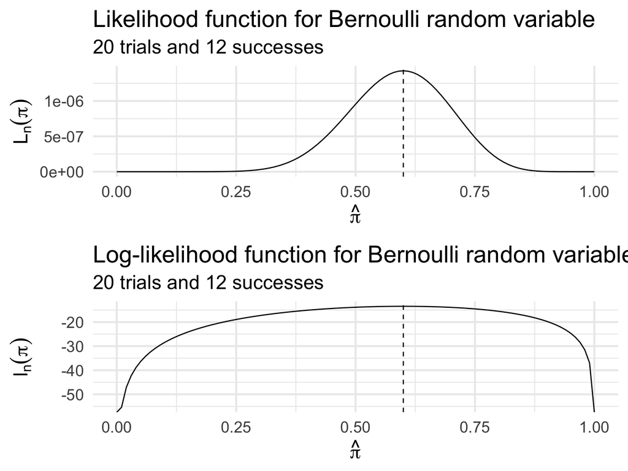

## Example: Normal distribution

- Let $X_1, \ldots, X_n \sim N(\mu, \sigma^2)$
- $\theta = (\mu, \sigma)$
- (Simplified) likelihood function

  $$\begin{align}
  \Lagr_n (\mu, \sigma) &= \prod_i \frac{1}{\sigma} \exp \left[ - \frac{1}{2\sigma^2} (X_i - \mu)^2 \right] \\
  &= \frac{1}{\sigma^n} \exp \left[ - \frac{1}{2\sigma^2} \sum_i (X_i - \mu)^2 \right] \\
  &= \frac{1}{\sigma^n} \exp \left[ \frac{n S^2}{2 \sigma^2} \right] \exp \left[ - \frac{n (\bar{X} - \mu)^2}{2 \sigma^2} \right]
  \end{align}$$
  - $\bar{X} = \frac{1}{n} \sum_i X_i$
  - $S^2 = \frac{1}{n} \sum_i (X_i - \bar{X})^2$
- Log-likelihood

  $$\lagr_n (\mu, \sigma) = -n \log \sigma - \frac{nS^2}{2\sigma^2} - \frac{n(\bar{X} - \mu)^2}{2\sigma^2}$$
  - $\hat{\mu} = \bar{X} = \E [X]$
  - $\hat{\sigma} = S = \sqrt{\Var[X]}$

## Properties of maximum likelihood estimators

1. Consistency
2. Equivariant
3. Asymptotically Normal
4. Asymptotically optimal or efficient
5. Approximately the Bayes estimator
- Hold true for random variables with
  - Large sample sizes
  - Smooth conditions for $f(x; \theta)$

## Consistency

- $\hat{\theta}_n \xrightarrow{P} \theta_*$
- MLE converges in probability to the true value as the number of observations increases

## Equivariance

- If $\hat{\theta}_n$ is the MLE of $\theta$, then $g(\hat{\theta}_n)$ is the MLE of $g(\theta)$
- Functions applied to random variables
- Let $X_1, \ldots, X_n \sim N(\theta,1)$
  - MLE for $\theta$ is $\hat{\theta}_n = \bar{X}_n$
- Let $\tau = e^\theta$
  - MLE for $\tau$ is $\hat{\tau} = e^{\hat{\theta}} = e^{\bar{X}}$
- Explains equivalence between likelihood and log-likelihood

## Asymptotic normality

- Distribution of the MLE estimator is asymptotically normal
- $\se = \sqrt{\Var (\hat{\sigma}_n)}$

  $$\frac{\hat{\theta}_n - \theta_*}{\se} \leadsto N(0,1)$$

  $$\frac{\hat{\theta}_n - \theta_*}{\widehat{\se}} \leadsto N(0,1)$$
- Used to construct confidence intervals for ML point estimates
- Requires a large-ish sample size

## Optimality

  $$\sqrt{n} (\hat{\theta}_n - \theta) \leadsto N(0, \sigma^2)$$
- $\theta = \tilde{\theta}_n$ : median

  $$\sqrt{n} (\tilde{\theta}_n - \theta) \leadsto N \left(0, \sigma^2 \frac{\pi}{2} \right)$$
- Consider two estimators $T_n$ and $U_n$

  $$\begin{align}
  \sqrt{n} (T_n - \theta) &\leadsto N(0, t^2) \\
  \sqrt{n} (U_n - \theta) &\leadsto N(0, u^2) \\
  \end{align}$$
- Relative efficiency

  $$\text{ARE}(U, T) = \frac{t^2}{u^2}$$

## Optimality

- Relative efficiency for Normal distribution

  $$\text{ARE}(\tilde{\theta}_n, \hat{\theta}_n) = \frac{2}{\pi} \approx .63$$
- If $\hat{\theta}_n$ is the MLE and $\tilde{\theta}_n$ is any other estimator, then

  $$\text{ARE} (\tilde{\theta}_n, \hat{\theta}_n) \leq 1$$
- MLE has the smallest (asymptotic) variance
- MLE is efficient or asymptotically optimal

## Normal random variable

$$\Pr(X_i = x_i) = \frac{1}{\sqrt{2\pi\sigma^2}} \exp \left[\frac{(X_i - \mu)^2}{2\sigma^2}\right]$$

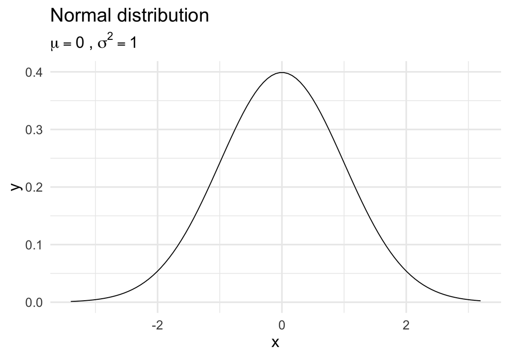

## MLE estimate

$$\begin{align}
\lagr_n(\mu, \sigma^2 | X) &= \log \prod_{i = 1}^{N}{\frac{1}{\sqrt{2\pi\sigma^2}} \exp \left[\frac{(X_i - \mu)^2}{2\sigma^2}\right]} \\
&= \sum_{i=1}^{N}{\log\left(\frac{1}{\sqrt{2\pi\sigma^2}} \exp \left[\frac{(X_i - \mu)^2}{2\sigma^2}\right]\right)} \\
&= -\frac{N}{2} \log(2\pi) - \left[ \sum_{i = 1}^{N} \ln{\sigma^2 - \frac{1}{2\sigma^2}} (X_i - \mu)^2 \right]
\end{align}$$

## Professor salaries

Salaries of assistant professors

| id | salary |
| --- | --- |
| 1 | 60 |
| 2 | 55 |
| 3 | 65 |
| 4 | 50 |
| 5 | 70 |

- MLE for $\hat{\mu}$ - average value of the random variable
- Treat $\sigma^2$ as a nuisance parameter
  - $\sigma^2 = c$

## MLE estimate $\hat{\mu}$

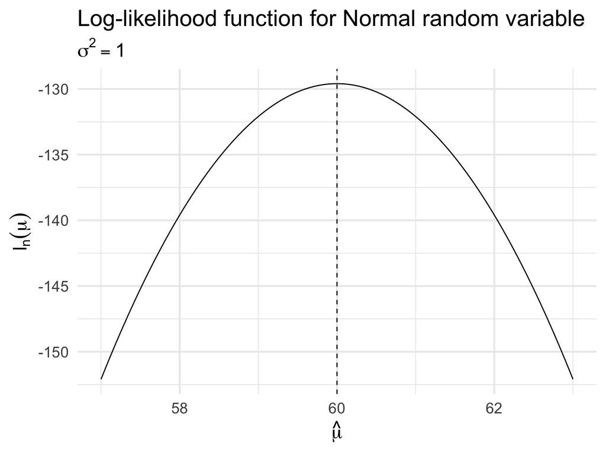

## MLE estimate $\hat{\mu}$

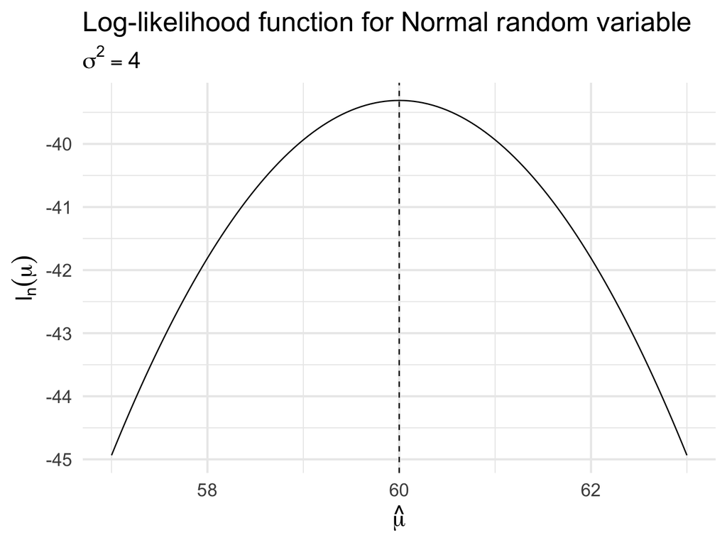

## Least squares regression

$$\E(Y) \equiv \mu = \beta_0 + \beta_{1}X_{i}$$

$$\Var (Y) = \sigma^2$$

$$\begin{align}
\lagr_n(\beta_0, \beta_1, \sigma^2 | Y, X) &= \log \left[ \prod_{i = 1}^{N}{\frac{1}{\sqrt{2\pi\sigma^2}} \exp \left[\frac{(Y_i - \beta_0 - \beta_{1}X_{i})^2}{2\sigma^2}\right]} \right] \\
&= -\frac{N}{2} \log(2\pi) \\
&\quad- \sum_{i = 1}^{N}\left[ \log{\sigma^2 - \frac{1}{2\sigma^2}} (Y_i - \beta_0 - \beta_{1}X_{i})^2 \right] \\
&\propto - \sum_{i = 1}^{N} \left[ \log{\sigma^2 - \frac{1}{2\sigma^2}} (Y_i - \beta_0 - \beta_{1}X_{i})^2 \right]
\end{align}$$

- Drop $\sigma^2$

  $$\lagr_n(\beta_0, \beta_1 | Y, X) = - \sum_{i = 1}^{N} (Y_i - \beta_0 - \beta_{1}X_{i})^2$$

## Least squares regression

$$\begin{align}
\dfrac{\partial{ \lagr_n(\beta_0, \beta_1 | Y, X)}}{\partial \beta_0} & = -2 (\sum_{i=1}^n (Y_i - \beta_0 - \beta_1 X_i))\\
& = \sum_{i=1}^n -2Y_i + 2\beta_0 + 2\beta_1 X_i\\
0 & = \sum_{i=1}^n -2Y_{i} + 2\beta_0 + 2\beta_1 X_i\\
0 & = -2 \sum_{i=1}^n Y_{i} + 2\sum_{i=1}^n \beta_0 + 2\beta_1 \sum_{i=1}^n X_i\\
0 & = -2 \sum_{i=1}^n Y_{i} + (n \times 2\beta_0) + 2\beta_1 \sum_{i=1}^n X_i\\
n \times 2\beta_0 & = 2 \sum_{i=1}^n Y_i - 2\beta_1 \sum_{i=1}^n X_i\\
\hat \beta_0 & = \dfrac{2 \sum_{i=1}^n Y_i}{2n} - \dfrac{2\beta_1 \sum_{i=1}^n X_i}{2n}\\
& = \dfrac{\sum_{i=1}^n Y_i}{n} - \beta_1\dfrac{ \sum_{i=1}^n X_i}{n}\\
\hat \beta_0 & = \bar{Y} - \beta_1 \bar{X}
\end{align}$$

## Least squares regression

$$\begin{align}
\dfrac{\partial{ \lagr_n(\beta_0, \beta_1 | Y, X)}}{\partial \beta_1} & = \sum_{i=1}^n -2X_i(Y_i - \beta_0 - \beta_1 X_i) \\
& = \sum_{i=1}^n -2Y_iX_i + 2\beta_0X_i + 2\beta_1 X_i^2\\
0 & = \sum_{i=1}^n -2Y_iX_i + 2\beta_0 \sum_{i=1}^nX_i + 2\beta_1 \sum_{i=1}^n X_i^2\\
& = \sum_{i=1}^n -2Y_iX_i + 2 (\bar{Y} - \beta_1 \bar{X}) \sum_{i=1}^nX_i + 2\beta_1 \sum_{i=1}^n X_i^2\\
& = \sum_{i=1}^n -2Y_iX_i + 2\bar{Y} \sum_{i=1}^nX_i - 2\beta_1 \bar{X}\sum_{i=1}^nX_i + 2\beta_1 \sum_{i=1}^n X_i^2\\
2\beta_1 \sum_{i=1}^n X_i^2 - 2\beta_1 \bar{X}\sum_{i=1}^nX_i & = \sum_{i=1}^n 2Y_iX_i - 2\bar{Y} \sum_{i=1}^nX_i\\
\beta_1 ( \sum_{i=1}^n X_i^2 - \bar{X}\sum_{i=1}^nX_i ) & = \sum_{i=1}^n Y_iX_i - \bar{Y} \sum_{i=1}^nX_i\\
\hat \beta_1 & = \dfrac{ \sum_{i=1}^n Y_iX_i - \bar{Y} \sum_{i=1}^nX_i}{ \sum_{i=1}^n X_i^2 - \bar{X}\sum_{i=1}^nX_i}\\
\hat \beta_0 & = \bar{Y} - \hat{\beta}_1 \bar{X}
\end{align}$$

## Computational calculation of the MLE

- Optimization problem
- Use optimization algorithms

## Grid search

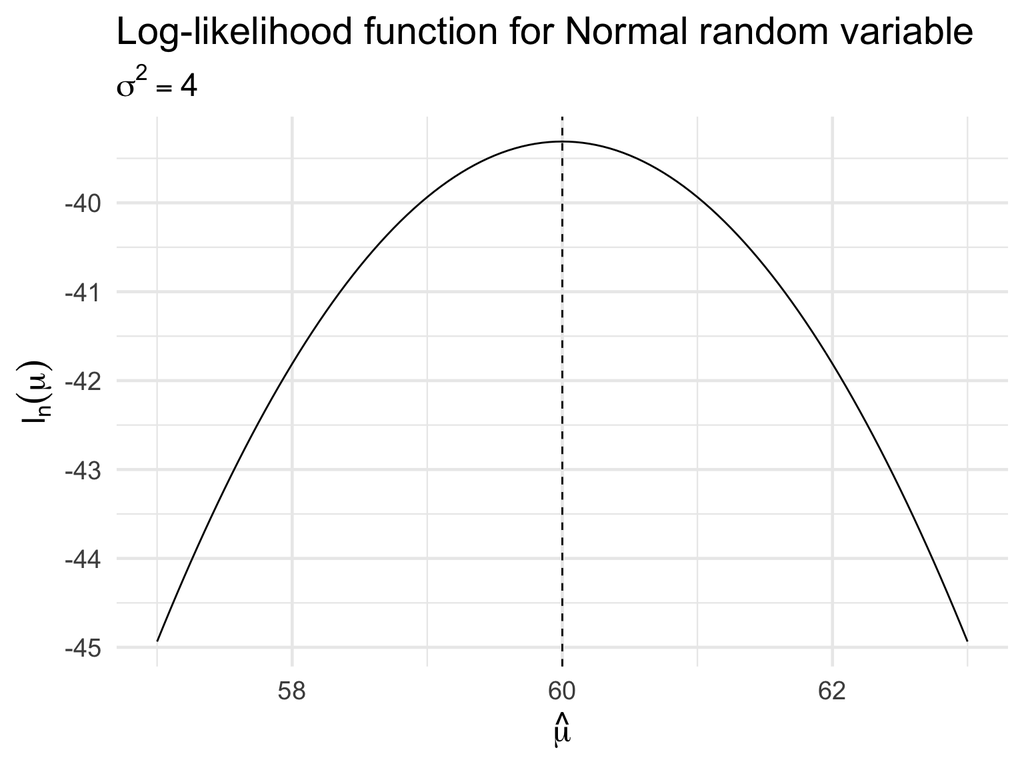

## Computational calculation of the MLE

```r
log_lik_lm <- function(par, data.y, data.x) {
  a.par <- par[1]  # The current slope
  b.par <- par[2]  # The current intercept
  err.sigma <- par[3]  # The current error standard deviation

  # Calculate the likelihood of each data point using dnorm
  likelihoods <- suppressWarnings(dnorm(data.y, mean = data.x * a.par + b.par, sd = err.sigma))

  # Calculate log-likelihoods of each data point
  log.likelihoods <- log(likelihoods)

  # return the sum of the log-likelihoods
  sum(log.likelihoods)
}

# optimize for professor salary
optim(par = c(1, 5, 20), fn = log_lik_lm, data.y = prof$salary, data.x = prof$years,
      control = list(fnscale = -1))
```

```
## $par
## [1] 5.00e+00 4.50e+01 2.46e-10
##
## $value
## [1] 106
##
## $counts
## function gradient
##      502       NA
##
## $convergence
## [1] 1
##
## $message
## NULL
```

```r
# compare to lm()
summary(lm(salary ~ years, data = prof))
```

```
##
## Call:
## lm(formula = salary ~ years, data = prof)
##
## Residuals:
##         1         2         3         4         5
## -1.28e-14  3.34e-15  3.17e-15  3.10e-15  3.19e-15
##
## Coefficients:
##             Estimate Std. Error  t value Pr(>|t|)
## (Intercept) 4.50e+01   8.67e-15 5.19e+15   <2e-16 ***
## years       5.00e+00   2.61e-15 1.91e+15   <2e-16 ***
## ---
## Signif. codes:  0 '***' 0.001 '**' 0.01 '*' 0.05 '.' 0.1 ' ' 1
##
## Residual standard error: 8.27e-15 on 3 degrees of freedom
## Multiple R-squared:     1,   Adjusted R-squared:     1
## F-statistic: 3.66e+30 on 1 and 3 DF,  p-value: <2e-16
```